# Identify X or Z Chromosomes from genotype data

Required:

- .vcf
- vcftools in path
- sex of individuals in your dataset (tab delimited)

Make list of chromosomes/scaffolds/contigs found in your .vcf

Take care not to have problematic characters such as ‘|’ in your scaffold names

The following is the code to run the vcftools –geno-depth and vcftools –het analyses in a shell script or can be submitted to a job scheduler with the proper header.

This will result in an output directory containing a file with the read depth of every locus for every individual (.gdepth) and observed and expected homozygosities, number of loci, and inbreeding coefficient (F) for each individual for each scaffold separately. Following vcftools, this script will concatenate all .het outputs and append scaffold information to produce a file all homozygosity values in a tab delimited format (.tsv).

```r
species=yourspecies
vcfile=yourgenotypes.vcf
chrfile=yourchr.txt
outdir=Homozygosities
homozygositiesfile=allhomozygosities.tsv

if [ ! -d "$outdir" ]; then
    mkdir $outdir
fi

cat $vcfile | grep -v "^#" | awk '{print $1}' | sort -u >$chrfile

for x in `cat $chrfile`
do
vcftools --vcf $vcfile --het --chr $x --out $outdir/$x
done

for x in `cat $chrfile`
do
cat $outdir/$x.het | awk -F '\t' -v i=$x -v OFS='\t' '{print 'i', $0}' | grep -v "O(HOM)" >>$homozygositiesfile
done

sed -i '1iScaffold\tIndv\tO.hom)\tE.hom)\tN\tF' $homozygositiesfile
vcftools --vcf $vcfile --geno-depth --out $yourspecies
```

Required libraries and function loaded by setup:

- tidyverse
- plyr
- broom
- dplyr
- ggplot2
- data_summary()

Below are R scripts to read in the locus depth file and heterozygosities file from above and a file you produce which contains the individual name (matching exactly with the individual name in the .vcf) and sex and appends sex information for all individuals to the augmented vcftools .het output.

The data frames are wrangled to create necessary data columns for analyses.

```r
depth <- depth %>%
  gather(Indv, G.depth, 3:ncol(depth)) %>%
  inner_join(sexes) %>%
  mutate(G.depth=replace(G.depth, G.depth==-1, 0)) %>%
  dplyr::select(Scaffold=CHROM, Position=POS, Depth=G.depth, Indv, Sex) %>%
  unite("Locus", Scaffold:Position, sep = "_")
```

[output not shown]

| Scaffold | PO.het_F | PO.het_M | sem_F | sem_M | estimate | estimate1 | estimate2 | statistic | p.value | parameter | conf.low | conf.high | method | alternative | Significant |
| --- | --- | --- | --- | --- | --- | --- | --- | --- | --- | --- | --- | --- | --- | --- | --- |
| NW_020662793.1 | 0.081673814 | 0.08173288 | 0.003949130 | 0.004210298 | -5.906344e-05 | 0.081673814 | 0.08173288 | -1.023179e-02 | 9.918551e-01 | 108.999992 | -0.0115000530 | 1.138193e-02 | Welch Two Sample t-test | two.sided | p-value >= 0.001 |
| NW_020662794.1 | 0.071119395 | 0.08632895 | 0.005206623 | 0.003205104 | -1.520956e-02 | 0.071119395 | 0.08632895 | -2.487640e+00 | 1.478691e-02 | 86.103510 | -0.0273636781 | -3.055434e-03 | Welch Two Sample t-test | two.sided | p-value >= 0.001 |
| NW_020662795.1 | 0.086619668 | 0.07481050 | 0.004981780 | 0.004938086 | 1.180917e-02 | 0.086619668 | 0.07481050 | 1.683543e+00 | 9.514722e-02 | 108.419372 | -0.0020941233 | 2.571246e-02 | Welch Two Sample t-test | two.sided | p-value >= 0.001 |
| NW_020662796.1 | 0.092342025 | 0.09342632 | 0.004063987 | 0.004966906 | -1.084294e-03 | 0.092342025 | 0.09342632 | -1.689551e-01 | 8.661507e-01 | 107.076199 | -0.0138064194 | 1.163783e-02 | Welch Two Sample t-test | two.sided | p-value >= 0.001 |
| NW_020662826.1 | 0.007803450 | 0.07477821 | 0.002473863 | 0.004258375 | -6.697476e-02 | 0.007803450 | 0.07477821 | -1.359946e+01 | 4.370624e-23 | 85.447252 | -0.0767658621 | -5.718366e-02 | Welch Two Sample t-test | two.sided | p-value < 0.001 |
| NW_020662831.1 | 0.007714524 | 0.08544913 | 0.002800829 | 0.006471075 | -7.773461e-02 | 0.007714524 | 0.08544913 | -1.102431e+01 | 1.269894e-17 | 78.628249 | -0.0917707079 | -6.369851e-02 | Welch Two Sample t-test | two.sided | p-value < 0.001 |
| NW_020662833.1 | 0.010616127 | 0.08542073 | 0.003112416 | 0.007177736 | -7.480460e-02 | 0.010616127 | 0.08542073 | -9.561536e+00 | 8.233688e-15 | 78.573548 | -0.0903781905 | -5.923102e-02 | Welch Two Sample t-test | two.sided | p-value < 0.001 |
| NW_020662839.1 | 0.080432983 | 0.08660289 | 0.004690220 | 0.004489722 | -6.169911e-03 | 0.080432983 | 0.08660289 | -9.502774e-01 | 3.440981e-01 | 107.740885 | -0.0190400143 | 6.700192e-03 | Welch Two Sample t-test | two.sided | p-value >= 0.001 |
| NW_020662860.1 | 0.013389002 | 0.07057006 | 0.002481129 | 0.004912634 | -5.718106e-02 | 0.013389002 | 0.07057006 | -1.038969e+01 | 8.386682e-17 | 85.067999 | -0.0681236268 | -4.623849e-02 | Welch Two Sample t-test | two.sided | p-value < 0.001 |
| NW_020662867.1 | 0.007375490 | 0.06167107 | 0.002022157 | 0.005596960 | -5.429558e-02 | 0.007375490 | 0.06167107 | -9.123688e+00 | 1.128666e-13 | 72.721089 | -0.0661567900 | -4.243438e-02 | Welch Two Sample t-test | two.sided | p-value < 0.001 |

[output cut: 190 more lines]

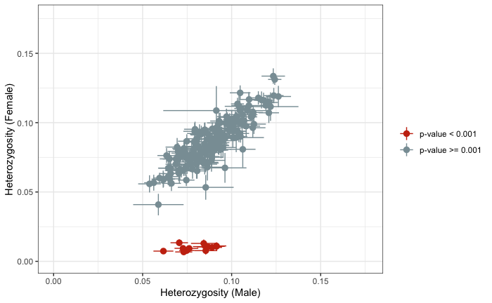

This table shows the X or Z linked scaffolds based on these analyses.

| Scaffold | PO.het_F | PO.het_M | sem_F | sem_M | p.value | method |
| --- | --- | --- | --- | --- | --- | --- |
| NW_020662826.1 | 0.007803450 | 0.07477821 | 0.002473863 | 0.004258375 | 4.370624e-23 | Welch Two Sample t-test |
| NW_020662831.1 | 0.007714524 | 0.08544913 | 0.002800829 | 0.006471075 | 1.269894e-17 | Welch Two Sample t-test |
| NW_020662833.1 | 0.010616127 | 0.08542073 | 0.003112416 | 0.007177736 | 8.233688e-15 | Welch Two Sample t-test |
| NW_020662860.1 | 0.013389002 | 0.07057006 | 0.002481129 | 0.004912634 | 8.386682e-17 | Welch Two Sample t-test |
| NW_020662867.1 | 0.007375490 | 0.06167107 | 0.002022157 | 0.005596960 | 1.128666e-13 | Welch Two Sample t-test |
| NW_020662870.1 | 0.006772833 | 0.07309043 | 0.002149154 | 0.004797339 | 1.036356e-20 | Welch Two Sample t-test |
| NW_020662873.1 | 0.012924537 | 0.08433378 | 0.002782166 | 0.007153357 | 3.981033e-14 | Welch Two Sample t-test |
| NW_020662887.1 | 0.009377872 | 0.07271302 | 0.001866751 | 0.004799424 | 1.179403e-19 | Welch Two Sample t-test |
| NW_020662899.1 | 0.010810387 | 0.09149748 | 0.002905604 | 0.004628999 | 2.034030e-26 | Welch Two Sample t-test |
| NW_020662910.1 | 0.011086982 | 0.09145821 | 0.001368605 | 0.005540230 | 2.009715e-21 | Welch Two Sample t-test |

[output cut: 3 more lines]

| Locus | Depth_F | Depth_M | sem_F | sem_M | p.value | Ratio |
| --- | --- | --- | --- | --- | --- | --- |
| NW_020662793.1_10000735 | 1.6226415 | 1.3278689 | 0.2305204 | 0.1993450 | 0.3356093232 | 1.2219893 |
| NW_020662793.1_10001432 | 1.7358491 | 2.2786885 | 0.1810126 | 0.2508250 | 0.0821663392 | 0.7617755 |
| NW_020662793.1_10001468 | 8.5094340 | 8.6229508 | 1.1747287 | 0.9596117 | 0.9404876675 | 0.9868355 |
| NW_020662793.1_10002176 | 1.6603774 | 1.3114754 | 0.2316462 | 0.1788564 | 0.2359774677 | 1.2660377 |
| NW_020662793.1_10003303 | 1.9056604 | 1.7049180 | 0.2904680 | 0.2353282 | 0.5924268693 | 1.1177431 |
| NW_020662793.1_10004059 | 4.2264151 | 5.0491803 | 0.7907491 | 0.8183103 | 0.4711719625 | 0.8370497 |
| NW_020662793.1_10005304 | 2.3207547 | 2.6721311 | 0.4136404 | 0.4749008 | 0.5780100488 | 0.8685033 |
| NW_020662793.1_10006323 | 1.5660377 | 1.3114754 | 0.2831881 | 0.1977206 | 0.4629036839 | 1.1941038 |
| NW_020662793.1_10006393 | 3.4716981 | 3.4754098 | 0.5029692 | 0.5404949 | 0.9959977780 | 0.9989320 |
| NW_020662793.1_10008153 | 4.2264151 | 5.0491803 | 0.9153748 | 0.8719760 | 0.5165223987 | 0.8370497 |

[output cut: 990 more lines]

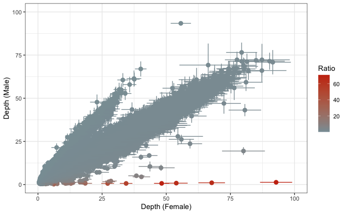

This table shows the W or Y linked scaffolds based on these analyses.

| Locus | Depth_F | Depth_M | sem_F | sem_M | p.value | Ratio |
| --- | --- | --- | --- | --- | --- | --- |
| NW_020662804.1_2692 | 92.811321 | 1.3114754 | 6.2593939 | 1.1955155 | 2.182701e-20 | 70.76863 |
| NW_020663749.1_5264 | 12.849057 | 0.6393443 | 1.5220671 | 0.1765374 | 1.195324e-10 | 20.09724 |
| NW_020664102.1_4042 | 48.207547 | 0.6885246 | 2.9703858 | 0.6062250 | 3.355608e-22 | 70.01572 |
| NW_020664128.1_7890 | 27.169811 | 0.6229508 | 2.4953856 | 0.5572002 | 8.957893e-15 | 43.61470 |
| NW_020664190.1_974 | 6.169811 | 0.2131148 | 0.5452898 | 0.1517021 | 2.951196e-15 | 28.95065 |
| NW_020664227.1_8905 | 34.358491 | 0.6557377 | 2.4585230 | 0.5411409 | 2.985752e-19 | 52.39670 |
| NW_020664256.1_6663 | 18.433962 | 0.7049180 | 2.6326229 | 0.2719533 | 1.364753e-08 | 26.15050 |
| NW_020664263.1_2744 | 53.905660 | 0.8360656 | 4.4404023 | 0.6879844 | 1.189277e-16 | 64.47540 |
| NW_020664322.1_4661 | 67.716981 | 1.0327869 | 5.1786921 | 0.9014158 | 5.444468e-18 | 65.56724 |